# COTWINS Grant Data

# Descriptives

There are 670 twins in the study. 658 have completed at least one checking in survey. 618 have at least one GPS point after data cleaning.

### Followup Rates

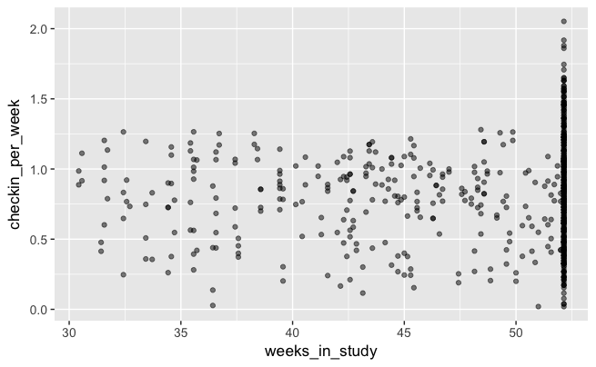

```r
checkin_rate <-
  remote_sub_use %>%
  group_by(user_id) %>%
  summarize(n = n()) %>%
  left_join(id_mapping_long, by = c("user_id" = "alternate_id")) %>%
  left_join(paper_data, by = c("SVID" = "ID1")) %>%
  mutate(time_in_study = as.duration(ymd("2017-05-31") - Test_Date)) %>%
  mutate(time_in_study = if_else(time_in_study <= dyears(1), time_in_study, dyears(1))) %>%
  mutate(
  weeks_in_study = as.numeric(time_in_study) / 604800,
  checkin_per_week = n / (as.numeric(time_in_study) / 604800)
  ) %>%
  select(
    user_id,
    n,
    Test_Date,
    time_in_study,
    checkin_per_week,
    weeks_in_study)

  ggplot(checkin_rate, aes(x = weeks_in_study, y = checkin_per_week)) + geom_point(alpha = 0.5)
```

78.4% of twins have a Checking In completion rate of greater than 50%.

### Sample Composition

```r
paper_data %>%
  mutate(Sex1 = as.numeric(Sex1)) %>%
  mutate(Sex1 = recode(Sex1, `1` = "Female", `2` = "Male")) %>%
  group_by(Zygosity = bestzygos, Sex = Sex1) %>%
  summarize(
    N = n(),
    `Mean Age at Assessment` = comma(mean(as.numeric(Test_Age / 365)))
    )
```

| Zygosity | Sex | N | Mean Age at Assessment |
| --- | --- | --- | --- |
| DZ | Female | 148 | 15.9 |
| DZ | Male | 126 | 16.2 |
| MZ | Female | 134 | 16.3 |
| MZ | Male | 86 | 16.2 |
| OS | Female | 88 | 15.9 |
| OS | Male | 88 | 15.9 |

### Birth Years

```r
paper_data %>%
  group_by(Birth_Year) %>%
  summarize(N = n())
```

| Birth_Year | N |
| --- | --- |
| 1997 | 2 |
| 1998 | 114 |
| 1999 | 221 |
| 2000 | 170 |
| 2001 | 113 |
| 2002 | 50 |

# Validation of Remote Measures

The correlation between the in-person parental monitoring score and the first remote parental monitoring score for an individual.

```r
all_par_mon <-
  left_join(in_person_par, id_mapping_long, by = "SVID") %>%
  left_join(
    distinct(remote_par, user_id, .keep_all = T),
    by = c("alternate_id" = "user_id")
    )
cor(all_par_mon$max_monitor_score.x, all_par_mon$max_monitor_score.y, use = "complete.obs")
```

```
[1] 0.5748954
```

The correlation between the first and second remote parental monitoring scores for an individual.

```r
lagged_remote <-
  remote_par %>%
  group_by(user_id) %>%
  summarize(
    first_mon = first(max_monitor_score),
    second_mon = nth(max_monitor_score, 2)
    )
cor(lagged_remote$first_mon, lagged_remote$second_mon, use = "complete.obs")
```

```
[1] 0.6546253
```

The correlations are very similar, suggesting that any change due to the nature of the assessment is small compared to the week to week changes in the score.

# Twin Discordance

```r
tp_phenx <-
  left_join(id_mapping, phenx_diagnoses, by = c("T1" = "SVID")) %>%
  left_join(phenx_diagnoses, by = c("T2" = "SVID"), suffix = c(".T1", ".T2"))
```

# Substance Use Trajectories

Get the subject’s age in years at survey completion for all of the remote substance use responses.

```r
remote_sub_use_age <-
  remote_sub_use %>%
  left_join(id_mapping_long, by = c("user_id" = "alternate_id")) %>%
  left_join(paper_data, by = c("SVID" = "ID1")) %>%
  mutate(age_at_completion = as.numeric(as_date(date_completed) - Birth_Date) / 365)
```

If the subject claimed no substance use or no use of the substance in question in a given response, set the quantity consumed or frequency of use to zero.

### Alcohol

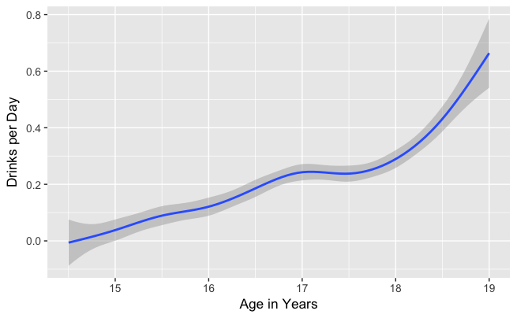

```r
remote_sub_use_age$alc_quantity_drinks_per_day[remote_sub_use_age$any_substance_use == FALSE] = 0
remote_sub_use_age$alc_quantity_drinks_per_day[remote_sub_use_age$alc_use == FALSE] = 0
ggplot(remote_sub_use_age, aes(x = age_at_completion, y = alc_quantity_drinks_per_day)) + geom_smooth() + xlab("Age in Years") + ylab("Drinks per Day") + xlim(14.5, 19)
```

### Marijuana

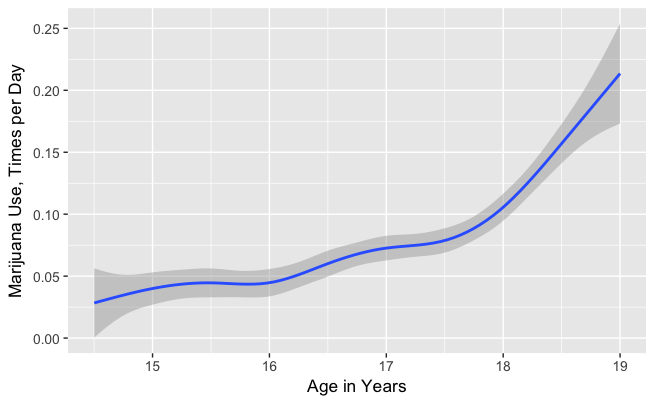

```r
remote_sub_use_age$mar_freq_times_per_day[remote_sub_use_age$any_substance_use == FALSE] = 0
remote_sub_use_age$mar_freq_times_per_day[remote_sub_use_age$mar_use == FALSE] = 0
ggplot(remote_sub_use_age, aes(x = age_at_completion, y = mar_freq_times_per_day)) + geom_smooth() + xlab("Age in Years") + ylab("Marijuana Use, Times per Day") + xlim(14.5, 19)
```

### Cigarettes

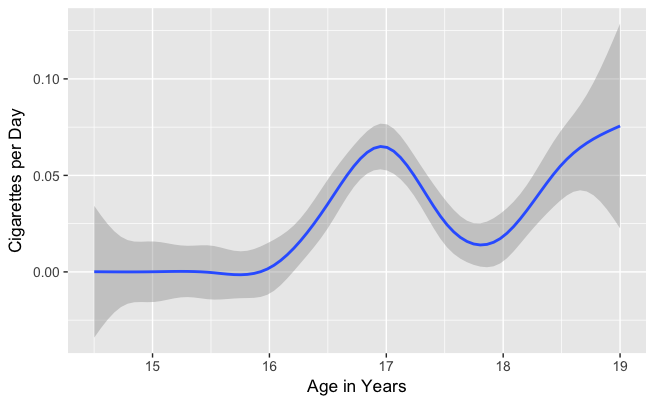

```r
remote_sub_use_age$cig_quantity_per_day[remote_sub_use_age$any_substance_use == FALSE] = 0
remote_sub_use_age$cig_quantity_per_day[remote_sub_use_age$cig_use == FALSE] = 0
ggplot(remote_sub_use_age, aes(x = age_at_completion, y = cig_quantity_per_day)) + geom_smooth() + xlab("Age in Years") + ylab("Cigarettes per Day") + xlim(14.5, 19)
```

### E-Cigarettes

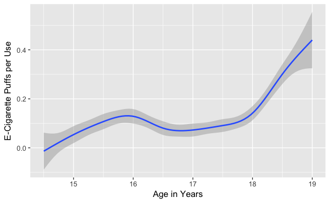

```r
remote_sub_use_age$ecig_quantity_puffs[remote_sub_use_age$any_substance_use == FALSE] = 0
remote_sub_use_age$ecig_quantity_puffs[remote_sub_use_age$ecig_use == FALSE] = 0
ggplot(remote_sub_use_age, aes(x = age_at_completion, y = ecig_quantity_puffs)) + geom_smooth() + xlab("Age in Years") + ylab("E-Cigarette Puffs per Use") + xlim(14.5, 19)
```

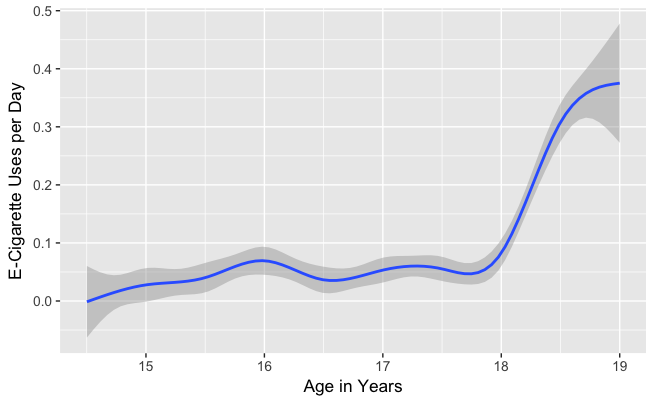

```r
remote_sub_use_age$ecig_freq_times_per_day[remote_sub_use_age$any_substance_use == FALSE] = 0
remote_sub_use_age$ecig_freq_times_per_day[remote_sub_use_age$ecig_use == FALSE] = 0
ggplot(remote_sub_use_age, aes(x = age_at_completion, y = ecig_freq_times_per_day)) + geom_smooth() + xlab("Age in Years") + ylab("E-Cigarette Uses per Day") + xlim(14.5, 19)
```